# Tugas Pertemuan 4 Praktikum MPDW

Qurrota A’yunina

2026-09-12

# PROSES MA(2)

```r
library(TSA)
set.seed(123) # Mengunci seed agar hasil acak selalu konstan/sama
```

## 1. BANGKITKAN MODEL MA(2)

```r
# ------------------------------------------------------------------------------
# 1. BANGKITKAN MODEL MA(2)
# ------------------------------------------------------------------------------
# Parameter: theta_1 = 0.4, theta_2 = 0.6, n = 300
# Persamaan MA(2): Y_t = e_t + theta_1 * e_{t-1} + theta_2 * e_{t-2}

n <- 300
theta1 <- 0.4
theta2 <- 0.6
e <- rnorm(n, mean = 0, sd = 1) # White noise ~ N(0,1)

# A. Pembangkitan Manual
y_manual <- numeric(n)
y_manual[1] <- e[1]
y_manual[2] <- e[2] + theta1 * e[1]

for (t in 3:n) {
  y_manual[t] <- e[t] + theta1 * e[t - 1] + theta2 * e[t - 2]
}

# B. Pembangkitan menggunakan fungsi arima.sim()
y_sim <- arima.sim(model = list(ma = c(theta1, theta2)), n = n)
```

## 2. PLOT TIME SERIES, ACF, PACF, EACF & IDENTIFIKASI STASIONERITAS

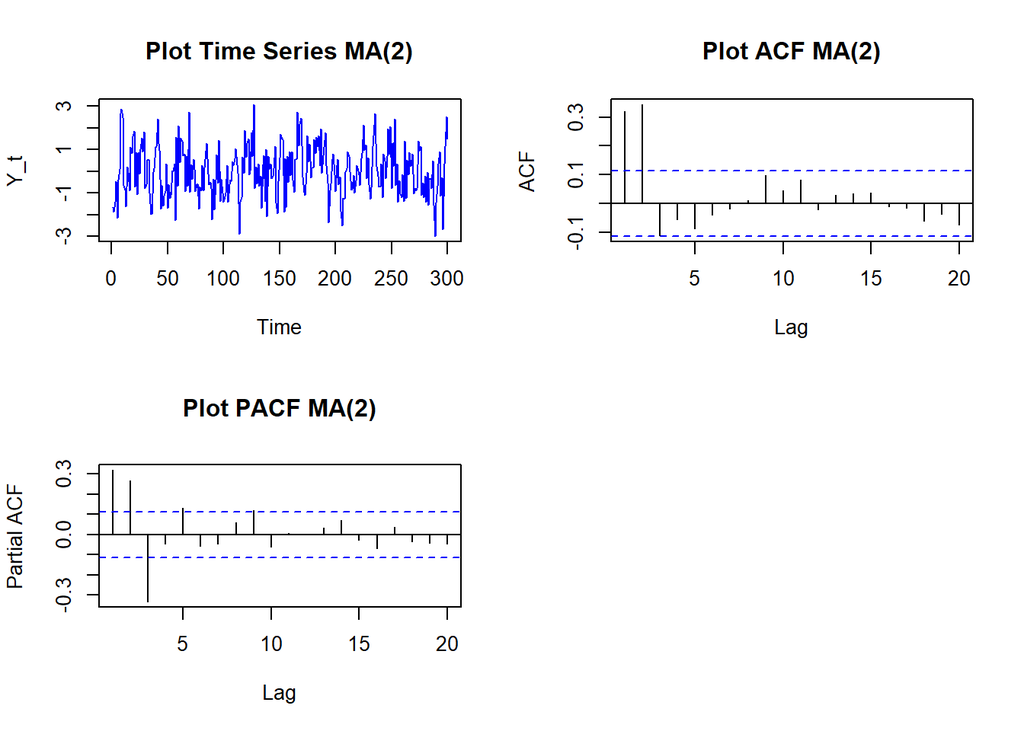

```r
# ------------------------------------------------------------------------------
# 2. PLOT TIME SERIES, ACF, PACF, EACF & IDENTIFIKASI STASIONERITAS
# ------------------------------------------------------------------------------
# Mengatur layout plot (2x2)
par(mfrow = c(2, 2))

# Plot Time Series
plot.ts(y_sim, main = "Plot Time Series MA(2)", ylab = "Y_t", col = "blue")

# Plot ACF (Autocorrelation Function)
# MA(2) secara teoritis akan cut off setelah lag 2
acf(y_sim, lag.max = 20, main = "Plot ACF MA(2)")

# Plot PACF (Partial Autocorrelation Function)
# PACF untuk MA(2) akan membuntut (tails off/dies down)
pacf(y_sim, lag.max = 20, main = "Plot PACF MA(2)")

# Kembali ke layout plot normal (1x1)
par(mfrow = c(1, 1))
```

```r
# Plot EACF (Extended ACF)
cat("\n--- Extended ACF (EACF) ---\n")
```

```
##
## --- Extended ACF (EACF) ---
```

```r
eacf(y_sim)
```

```
## AR/MA
##   0 1 2 3 4 5 6 7 8 9 10 11 12 13
## 0 x x o o o o o o o o o  o  o  o
## 1 x x x o o o o o o o o  o  o  o
## 2 x x x x o o o o o o o  o  o  o
## 3 x x x o o o o o o o o  o  o  o
## 4 x x x o o x o o o o o  o  o  o
## 5 x x o o o x x o o o o  o  o  o
## 6 x x o o x x x x o o o  o  o  o
## 7 x x o x x x x x x o o  o  o  o
```

## 3. SCATTERPLOT Y_t DENGAN Y_{t-1}, Y_{t-2}, DAN Y_{t-3}

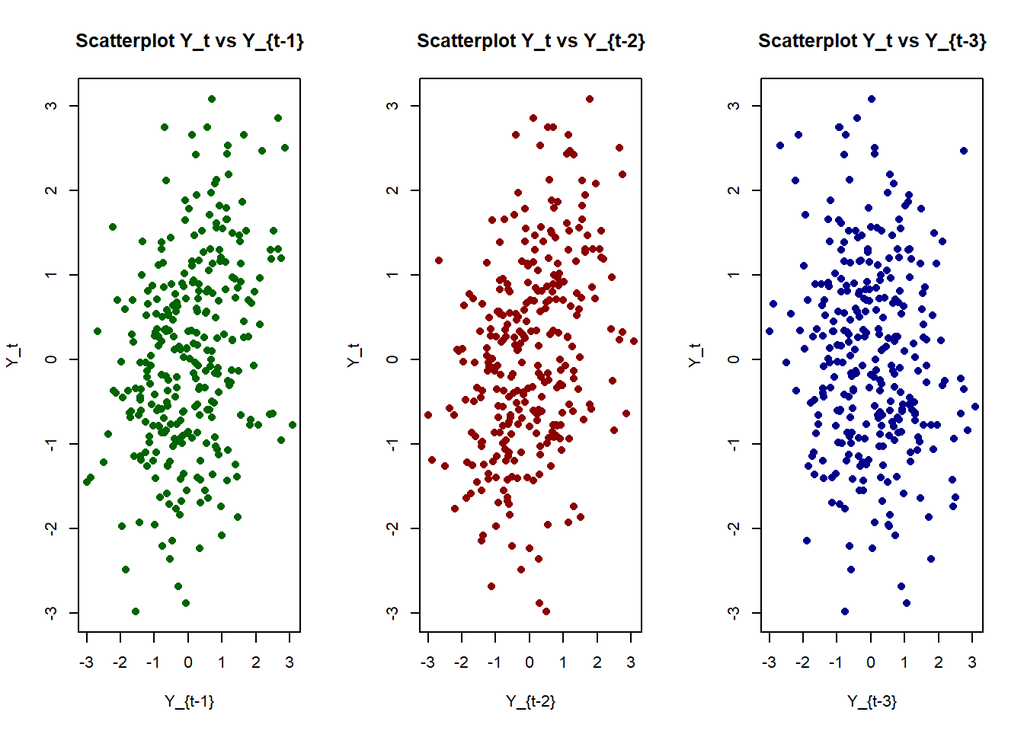

```r
# ------------------------------------------------------------------------------
# 3. SCATTERPLOT Y_t DENGAN Y_{t-1}, Y_{t-2}, DAN Y_{t-3}
# ------------------------------------------------------------------------------
# Membuat lag data
yt   <- y_sim[4:n]
yt_1 <- y_sim[3:(n-1)]
yt_2 <- y_sim[2:(n-2)]
yt_3 <- y_sim[1:(n-3)]

par(mfrow = c(1, 3))
plot(yt_1, yt, main = "Scatterplot Y_t vs Y_{t-1}", xlab = "Y_{t-1}", ylab = "Y_t", col = "darkgreen", pch = 16)
plot(yt_2, yt, main = "Scatterplot Y_t vs Y_{t-2}", xlab = "Y_{t-2}", ylab = "Y_t", col = "darkred", pch = 16)
plot(yt_3, yt, main = "Scatterplot Y_t vs Y_{t-3}", xlab = "Y_{t-3}", ylab = "Y_t", col = "darkblue", pch = 16)
```

```r
par(mfrow = c(1, 1))
```

## 4. PERHITUNGAN AUTOKORELASI (TEORITIS VS BANGKITAN)

```r
# ------------------------------------------------------------------------------
# 4. PERHITUNGAN AUTOKORELASI (TEORITIS VS BANGKITAN)
# ------------------------------------------------------------------------------

# A. Nilai Autokorelasi Teoritis
denom <- 1 + theta1^2 + theta2^2
rho1_teoritis <- theta1 * (1 + theta2) / denom
rho2_teoritis <- theta2 / denom
rho3_teoritis <- 0

# B. Nilai Autokorelasi Data Pembangkitan (Empiris)
# Dibungkus as.vector() agar nilainya tidak bergeser di tabel
# Panggil sintaks awalmu, lalu tambahkan nilai Lag 0 (1) di depannya
acf_empiris <- c(1, acf(y_sim, plot = FALSE)$acf[1:3])

tabel_hasil <- data.frame(
  Lag = c("Lag 0", "Lag 1", "Lag 2", "Lag 3"),
  Teoritis = c(1, rho1_teoritis, rho2_teoritis, rho3_teoritis),
  Empiris = acf_empiris
)

cat("\n--- PERBANDINGAN AUTOKORELASI ---\n")
```

```
##
## --- PERBANDINGAN AUTOKORELASI ---
```

```r
print(tabel_hasil)
```

```
##     Lag  Teoritis    Empiris
## 1 Lag 0 1.0000000  1.0000000
## 2 Lag 1 0.4210526  0.3199234
## 3 Lag 2 0.3947368  0.3434607
## 4 Lag 3 0.0000000 -0.1112481
```

**Interpretasi**

1. Identifikasi Stasioneritas & Pola Plot (ACF, PACF, EACF)
- **Plot Time Series:** Data berfluktuasi secara acak di sekitar rata-rata nol (mean = 0) dengan varians yang relatif konstan. Tidak terlihat tren naik/turun maupun pola musiman. Artinya, **data sudah stasioner**.
- **Plot ACF:** Signifikan (keluar garis batas biru) pada **lag 1 dan lag 2**, lalu *cut off* (masuk dalam batas kepercayaan) mulai lag 3. Pola *cut off* pada lag 2 menunjukkan karakteristik utama dari proses **MA(2)**.
- **Plot PACF:** Terlihat pola meluruh secara perlahan (*tails off / dies down*), yang mengonfirmasi bahwa model bersifat Moving Average.
- **Matriks EACF:** Membentuk sudut segitiga bernilai `o` (tidak signifikan) yang diawali pada **baris AR = 0** dan **kolom MA = 2**. Hal ini menegaskan bahwa model tentatif terbaik adalah **MA(2)**.
2. Interpretasi Scatterplot
- **$Y_t$ vs $Y_{t-1}$ & $Y_t$ vs $Y_{t-2}$:** Terbentuk pola hubungan linier positif (sebaran titik cenderung miring ke kanan atas). Ini menunjukkan adanya korelasi positif yang cukup kuat pada lag 1 dan lag 2.
- **$Y_t$ vs $Y_{t-3}$:** Sebaran titik berbentuk lingkaran acak tanpa pola linier. Hal ini mengindikasikan **tidak ada korelasi** antara $Y_t$ dengan $Y_{t-3}$ (korelasi mendekati 0), sesuai dengan sifat MA(2) yang terputus setelah lag 2.
3. Perbandingan Autokorelasi (Teoritis vs Empiris)

Secara keseluruhan, nilai autokorelasi empiris dari data bangkitan ($n = 300$) menunjukkan pola yang sangat konsisten dengan nilai autokorelasi teoritisnya. Pada Lag 0, nilainya sempurna bernilai $1,0000$. Pada Lag 1 dan Lag 2, terdapat korelasi positif yang signifikan dengan nilai teoritis berturut-turut sebesar $0,4211$ dan $0,3947$, sedangkan nilai empiris dari data bangkitan sebesar $0,3199$ pada Lag 1 dan $0,3435$ pada Lag 2. Selanjutnya pada Lag 3, nilai autokorelasi turun drastis mendekati nol, di mana nilai teoritisnya adalah $0,0000$ dan nilai empirisnya sebesar $-0,1112$. Sedikit perbedaan angka antara teoritis dan empiris merupakan hal yang wajar akibat adanya variasi acak (sampling error) pada proses simulasi data.

# PROSES AR(2)

```r
library(TSA)

set.seed(123) # Mengunci seed agar hasil simulasi konsisten
```

## 1. BANGKITKAN MODEL AR(2)

```r
# ------------------------------------------------------------------------------
# 1. BANGKITKAN MODEL AR(2)
# ------------------------------------------------------------------------------
# Parameter: phi_1 = 0.5, phi_2 = 0.2, n = 300
# Persamaan AR(2): Y_t = phi_1 * Y_{t-1} + phi_2 * Y_{t-2} + e_t

n <- 300
phi1 <- 0.5
phi2 <- 0.2
e <- rnorm(n, mean = 0, sd = 1) # White noise ~ N(0,1)

# A. Pembangkitan Manual
y_manual <- numeric(n)
y_manual[1] <- e[1]
y_manual[2] <- phi1 * y_manual[1] + e[2]

for (t in 3:n) {
  y_manual[t] <- phi1 * y_manual[t - 1] + phi2 * y_manual[t - 2] + e[t]
}

# B. Pembangkitan menggunakan fungsi arima.sim()
y_sim <- arima.sim(model = list(ar = c(phi1, phi2)), n = n)
```

## 2. PLOT TIME SERIES, ACF, PACF, EACF & IDENTIFIKASI STASIONERITAS

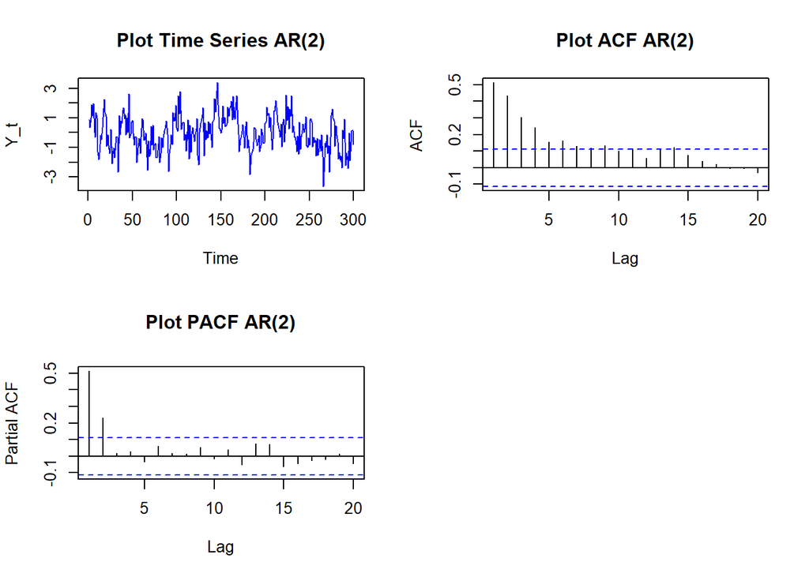

```r
# ------------------------------------------------------------------------------
# 2. PLOT TIME SERIES, ACF, PACF, EACF & IDENTIFIKASI STASIONERITAS
# ------------------------------------------------------------------------------
# Layout plot (2x2)
par(mfrow = c(2, 2))

# Plot Time Series
plot.ts(y_sim, main = "Plot Time Series AR(2)", ylab = "Y_t", col = "blue")

# Plot ACF (Autocorrelation Function)
# ACF untuk AR(2) akan meluruh perlahan (tails off / dies down)
acf(y_sim, lag.max = 20, main = "Plot ACF AR(2)")

# Plot PACF (Partial Autocorrelation Function)
# PACF untuk AR(2) akan cut off setelah lag 2
pacf(y_sim, lag.max = 20, main = "Plot PACF AR(2)")

# Layout normal
par(mfrow = c(1, 1))
```

```r
# Plot EACF (Extended ACF)
cat("\n--- Extended ACF (EACF) ---\n")
```

```
##
## --- Extended ACF (EACF) ---
```

```r
eacf(y_sim)
```

```
## AR/MA
##   0 1 2 3 4 5 6 7 8 9 10 11 12 13
## 0 x x x x x x x x x o o  o  o  x
## 1 x o o o o o o o o o o  o  o  o
## 2 o x o o o o o o o o o  o  o  o
## 3 x o o o o o o o o o o  o  o  o
## 4 x x o x o o o o o o o  o  o  o
## 5 x x x o o o o o o o o  o  o  o
## 6 x o x x o o o o o o o  o  o  o
## 7 x o x x x o o o o o o  o  o  o
```